# Capital One Data Challenge

## Capital One Data Challenge - Kevin Dewandeler

## 1. Quality Check

### Importing packages, loading data

```python
## Importing all necessary packages
import pandas as pd
import matplotlib.pyplot as plt
import seaborn as sns
import numpy as np
import math
import json
import folium
import warnings
warnings.filterwarnings('ignore')

pd.set_option('display.max_columns', None)
pd.set_option('display.max_rows', 1000)
pd.set_option('display.float_format', lambda x: '%.3f' % x)

## Reading in data, converting price column in AirBnb data to numeric
br_df = pd.read_csv('Zip_Zhvi_2bedroom.csv')
listings = pd.read_csv('listings.csv.gz', compression = 'gzip')
listings['price'] = listings['price'].replace('[\$,]', '', regex=True).astype(float)
date_cols = br_df.columns[7:]
last_10_yrs = date_cols[135:]

with open('ny_test.json') as f:
    nyArea = json.load(f)

# data from https://www.health.ny.gov/statistics/cancer/registry/appendix/neighborhoods.htm
# This data is used as the source of truth for NYC zip codes
zip_df = pd.read_csv('nyc_zip_codes.csv')

for i in range(10):
    if i != 0:
        zip_df[('Zip' + str(i))] = zip_df[('Zip' + str(i))].fillna(0).astype(int).astype(str)

ny_zip_list = pd.unique(zip_df[['Zip1','Zip2','Zip3','Zip4','Zip5','Zip6','Zip7','Zip8','Zip9']].values.ravel('K')).tolist()
ny_zip_list.remove('0')
```

```python
br_df['State'].unique()
```

```
array(['NY', 'IL', 'TX', 'CA', 'FL', 'TN', 'NC', 'GA', 'DC', 'MD', 'MO',
       'VA', 'NJ', 'OK', 'OH', 'AZ', 'KS', 'NM', 'WA', 'CT', 'NV', 'MA',
       'PA', 'MI', 'CO', 'KY', 'OR', 'SC', 'IN', 'ND', 'AR', 'AL', 'MN',
       'DE', 'MS', 'ID', 'MT', 'WI', 'HI', 'UT', 'LA', 'RI', 'IA', 'NE',
       'WY', 'AK', 'NH', 'WV'], dtype=object)
```

```python
br_df[br_df['State'] == 'NY']['RegionName'].unique()[:10]
```

```
array([10025, 10023, 10128, 10011, 10003, 11201, 11234, 10314, 11215,
       14850], dtype=int64)
```

Data Quality Insight 1. The Zillow dataset appears very clean - the states and zip codes have no apparent issues.

```python
listings['state'].unique()
```

```
array(['NY', nan, 'Ny', 'ny', 'MP', 'CA', 'NJ', 'New York '], dtype=object)
```

Data Quality Insight 2. The listings dataset appears less clean - there are many state values that represent New York. I'll likely end up ignoring the 'state' value just to simplify, and focus on the 'zipcode' values.

```python
listings['zipcode'].unique()[165:190]
```

```
array(['11420', '10308', '11419', '11103-3233', '10474', '10002-2289',
       '10465', '10472', '11001', '11428', '11426', '11423', '11228',
       '10129', '11364', '11385-2308', '11363', '10281', '91766', '11362',
       '10174', '11413-3220', '07093', '10550', '11692-2304'],
      dtype=object)
```

Data Quality Insight 3. The listings dataset appears less clean - there are zip codes that don't follow the traditional 5 number format. I'll need to clean these up in order to merge the datasets together.

```python
def clean_zipcode(df):
    '''
    This function fixes zip code irregularities in the AirBnb listings data.
    '''

    df['zipcode'] = df['zipcode'].fillna(0).astype(str)
    df['zipcode'] = df['zipcode'].apply(lambda x: x[:5])

clean_zipcode(listings)
```

## 2. Data Munging

```python
airbnb_last_date = max(pd.to_datetime(listings['last_scraped']))
zillow_last_date = pd.to_datetime(br_df.columns[-1])
year_dif = (airbnb_last_date - zillow_last_date).days/365.25
```

```python
## Difference in dates between Zillow real estate data and AirBnb listing data
year_dif
```

```
2.102669404517454
```

```python
def zillow_annual_growth(df):
    '''
    This function takes the last 10 years of Zillow data and returns a dataframe with average year-over-year growth of
    2br real estate value by zip code.

    This function was created because the Zillow data is from 6/2017, while the AirBnb data is from 7/2019.
    I needed a way to estimate the real estate value for 2019, approximately 2 years later.

    If I know the average annual growth of real estate value by zip code, I can estimate what the real estate
    value would be in 2019, which will align with the AirBnb data.
    '''

    zip_dict = {}

    ## Taking the real estate value annually (once every 12 months)
    for row in range(len(df)):
        costs = []
        rolling_annual_growth = []

        for i in last_10_yrs:
            costs.append(df[i][row])

            if len(costs) % 12 == 0:
                rolling_annual_growth.append(np.mean(costs[-12:]))
                zip_dict.update({df['RegionName'][row] : rolling_annual_growth})
            else:
                continue

    rolling_growth_dict = {}

    ## Calculating real estate growth from the last 10 years
    for key in zip_dict.keys():
        avg_growth = []
        for num in range(len(zip_dict[key])):
            if num != 0:
                avg_growth.append((zip_dict[key][num] - zip_dict[key][num-1])/zip_dict[key][num-1])
        rolling_growth_dict.update({key : avg_growth})

    growth_dict = {}

    ## Averaging the 10 year growth numbers into one average annual growth
    for key in rolling_growth_dict.keys():
        avg_growth = np.mean(rolling_growth_dict[key])
        growth_dict.update({key : avg_growth})

    growth_df = pd.DataFrame.from_dict(growth_dict, orient = 'index').reset_index()
    growth_df = growth_df.rename(columns = {'index' : 'zip', 0 : 'growth'})
    growth_df['zip'] = growth_df['zip'].astype(str)

    return growth_df
```

```python
## Filtering the Zillow data for only NYC
ny_br_df = br_df[br_df['RegionName'].isin(ny_zip_list)].reset_index(drop = True)

## Calculating average annual growth for NYC Zillow data
growth_df = zillow_annual_growth(ny_br_df)

## Calculating median real estate value by zip code
zip_cost = ny_br_df.groupby('RegionName')['2017-06'].agg('median').sort_values(ascending = False).reset_index()
zip_cost['RegionName'] = zip_cost['RegionName'].astype(str)

## Filtering the AirBnb data for only NYC; converting median price by zip code to annual income, assuming 75% occupancy
ny_listings = listings[listings['zipcode'].isin(ny_zip_list)].groupby('zipcode')['price'].agg(['count','median']).reset_index()
ny_listings['annual_income'] = (ny_listings['median']*0.75*365.25).round(2)
ny_listings = ny_listings.rename(columns = {'count' : 'AirBnb listings by zipcode'})

## Merging data sources together to create master dataframe that contains
## cost data, income data, and, created below, profit data
profit_df = pd.merge(growth_df, pd.merge(ny_listings[['zipcode','AirBnb listings by zipcode','annual_income']], zip_cost,
                    left_on = 'zipcode', right_on = 'RegionName'), left_on = 'zip', right_on = 'zipcode')
del profit_df['RegionName']
del profit_df['zip']

## Converting Zillow real estate value to 2019 values using the difference in dates between data sources
## This will work for future data being added, but column names will need to be adjusted in the future
profit_df['2019_cost_est'] = pow((1 + profit_df['growth']), year_dif)*profit_df['2017-06']

## Calculating various levels of profit numbers
profit_df['1yr_profit'] = profit_df['annual_income'] - profit_df['2019_cost_est']
profit_df['5yr_profit'] = (profit_df['annual_income'] * 5) - profit_df['2019_cost_est']
profit_df['10yr_profit'] = (profit_df['annual_income'] * 10) - profit_df['2019_cost_est']
profit_df['30yr_profit'] = (profit_df['annual_income'] * 30) - profit_df['2019_cost_est']
profit_df['50yr_profit'] = (profit_df['annual_income'] * 50) - profit_df['2019_cost_est']
profit_df['zipcode'] = profit_df['zipcode'].astype(int).astype(str)
```

```python
profit_df.head()
```

|  | growth | zipcode | AirBnb listings by zipcode | annual_income | 2017-06 | 2019_cost_est | 1yr_profit | 5yr_profit | 10yr_profit | 30yr_profit | 50yr_profit |
| --- | --- | --- | --- | --- | --- | --- | --- | --- | --- | --- | --- |
| 0 | 0.043 | 10025 | 1009 | 30133.120 | 1431000 | 1562390.370 | -1532257.250 | -1411724.770 | -1261059.170 | -658396.770 | -55734.370 |
| 1 | 0.032 | 10023 | 499 | 50678.440 | 2142300 | 2289042.806 | -2238364.366 | -2035650.606 | -1782258.406 | -768689.606 | 244879.194 |
| 2 | 0.041 | 10128 | 415 | 36981.560 | 1787100 | 1944874.205 | -1907892.645 | -1759966.405 | -1575058.605 | -835427.405 | -95796.205 |
| 3 | 0.046 | 10011 | 840 | 54787.500 | 2480400 | 2725829.660 | -2671042.160 | -2451892.160 | -2177954.660 | -1082204.660 | 13545.340 |
| 4 | 0.036 | 10003 | 1035 | 46569.380 | 2147000 | 2315096.354 | -2268526.974 | -2082249.454 | -1849402.554 | -918014.954 | 13372.646 |

## 3. Crafting a visual narrative

```
Text(0,-1.5e+06,'Best 10 year profits\ncome from zip codes\nwith low AirBnb competition')
```

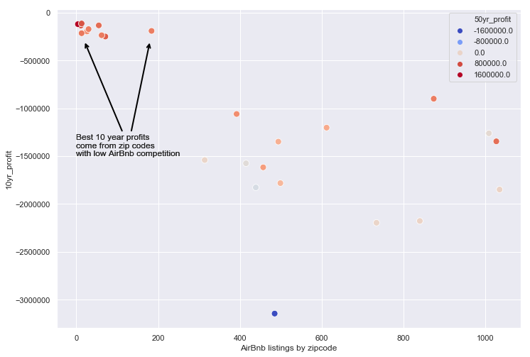

```python
sns.set(rc={'figure.figsize':(11.7,8.27)})
sns.scatterplot(profit_df['AirBnb listings by zipcode'], profit_df['10yr_profit'] ,hue = profit_df['50yr_profit'],
               palette = 'coolwarm', s = 80)
plt.annotate('Best 10 year profits\ncome from zip codes\nwith low AirBnb competition', xy  = (20, -300000),
             xytext = (0, -1500000), arrowprops = dict(arrowstyle = '->, head_width = 0.2', linewidth = 2, color = 'black'))
plt.annotate('Best 10 year profits\ncome from zip codes\nwith low AirBnb competition', xy  = (180, -300000),
             xytext = (0, -1500000), arrowprops = dict(arrowstyle = '->, head_width = 0.2', linewidth = 2, color = 'black'))
```

```python
## Filtering geo data to only include zip codes that have been used in this analysis, for later plotting
filtered_list = []

for i in nyArea['features']:
    if i['properties']['postalCode'] in profit_df['zipcode'].tolist():
        filtered_list.append(i)

nyArea['features'] = filtered_list
```

```python
nyMap = folium.Map(location=[40.7128, -74.0060], tiles='Stamen Toner', zoom_start=10)
```

```python
nyMap.choropleth(geo_data=nyArea, data=profit_df, columns=['zipcode', '10yr_profit'],
                 key_on='properties.postalCode', fill_color='RdYlGn', fill_opacity=1)


#nyMap.save('nyChoropleth_10yr_profit.html')
```

```python
nyMap
```

Make this Notebook Trusted to load map: File -> Trust Notebook

[interactive chart not shown]

## Conclusion

The zip codes that are best to invest in depend on the timeframe that the investor is looking for. In this assignment, the buyer is purchasing the property with cash up front. This means the buyer is taking a huge loss in the beginning, but every year after that works to recoup his loss.

In the short term (1-10 years), it's best to invest in low-cost properties that have little AirBnb competition (Staten Island, as seen in attached graph). This is because the 'huge loss in the beginning' is much less huge. The buyer has a much smaller hole to dig him/herself out of, and can do so much more quickly.

```python
profit_df.sort_values(by = '5yr_profit', ascending = False)[['zipcode','5yr_profit']].head(10)
```

|  | zipcode | 5yr_profit |
| --- | --- | --- |
| 24 | 10303 | -222219.943 |
| 20 | 10304 | -230699.434 |
| 15 | 10312 | -247092.849 |
| 22 | 10309 | -258456.924 |
| 14 | 10306 | -263718.895 |
| 7 | 10314 | -279910.243 |
| 13 | 11434 | -285826.719 |
| 23 | 10308 | -316774.739 |
| 21 | 10305 | -338061.736 |
| 6 | 11234 | -370538.269 |

```python
profit_df.sort_values(by = '10yr_profit', ascending = False)[['zipcode','10yr_profit']].head(10)
```

|  | zipcode | 10yr_profit |
| --- | --- | --- |
| 24 | 10303 | -112644.943 |
| 22 | 10309 | -119433.624 |
| 20 | 10304 | -132081.934 |
| 15 | 10312 | -133408.799 |
| 14 | 10306 | -171264.995 |
| 13 | 11434 | -189948.619 |
| 7 | 10314 | -195674.443 |
| 23 | 10308 | -214048.189 |
| 21 | 10305 | -235335.186 |
| 6 | 11234 | -248636.069 |

```python
profit_df.sort_values(by = '50yr_profit', ascending = False)[['zipcode','50yr_profit']].head(10)
```

|  | zipcode | 50yr_profit |
| --- | --- | --- |
| 22 | 10309 | 992752.776 |
| 15 | 10312 | 776063.601 |
| 24 | 10303 | 763955.057 |
| 6 | 11234 | 726581.531 |
| 20 | 10304 | 656858.066 |
| 12 | 10036 | 649021.552 |
| 23 | 10308 | 607764.211 |
| 21 | 10305 | 586477.214 |
| 8 | 11215 | 579841.221 |
| 13 | 11434 | 577076.181 |

## 4. What's Next

In a future analysis, I would like to work with a more complete set of AirBnb zip codes. I ended up having only 25 zip codes that were available in all datasets, and this is why we see empty, white zip codes on the NYC map. It would be great to have the full picture of NYC available.

I would also like to have enhanced Zillow data that could break down property values by more factors (square footage, amenities, etc.). This would allow me to use much more data from the AirBnb dataset that I'm currently not able to use. For example, I might have found that 500 sq. foot Manhattan properties cost 2x as much as 2000 sq. foot Staten Island properties, but they can be rented out for 5x more. This would have enabled a layer of analysis that would be very interesting. I could have also found that properties with new furniture sell for 20% more, despite only costing 5% more.

All in all, I had a lot of fun working on this project. I hope you enjoyed reading through my analysis - I look forward to discussing next steps with the Capital One team!

Thanks, Kevin Dewandeler